# SPIPOLL exploration

François-Marie Martin

12 juin, 2023

# 1 Exploration préparatoire des données

## 1.1 Résumé général

Pour le moment, je ne présente que les traitements qui concernent l’ensemble des ordres d’arthropodes (potentiellement pollinisateurs), à savoir les 8 ordres suivants par ordre de fréquence décroissante: **diptères** (mouches, syrphes etc.), **hyménoptères** (abeilles, guêpes, fourmis etc.), **coléoptères** (carabes etc.), **lépidoptères** (papillons), **hémiptères** (punaises, pucerons etc.), **Aranéides** (araignées), **orthoptères** (sauterelles, grillons etc.), et **névroptères** (mantispe etc.). Je n’ai pas eu le temps de refaire tourner les analyses pour les 4 ordres principaux de pollinisateurs.

```
##    collection                 date                     flower_sp
##  56     :   1   26/05/2018 00:00:  21   Daucus_carota       :378
##  101    :   1   17/07/2020 00:00:  12   Taraxacum_spp       :264
##  112    :   1   07/07/2020 00:00:  11   Leucanthemum_spp    :260
##  121    :   1   11/08/2021 00:00:  10   Achillea_millefolium:230
##  129    :   1   01/08/2021 00:00:   9   Hedera_helix        :185
##  136    :   1   09/07/2019 00:00:   9   Centaurea_sp        :160
##  (Other):2173   (Other)         :2107   (Other)             :702
##  genus_richness   family_richness  order_richness     code_ua
##  Min.   : 0.000   Min.   : 1.000   Min.   :1.000   21000  :347
##  1st Qu.: 3.000   1st Qu.: 3.000   1st Qu.:2.000   23000  :323
##  Median : 5.000   Median : 6.000   Median :3.000   14100  :293
##  Mean   : 5.943   Mean   : 6.734   Mean   :3.262   11210  :244
##  3rd Qu.: 8.000   3rd Qu.:10.000   3rd Qu.:4.000   12100  :220
##  Max.   :31.000   Max.   :26.000   Max.   :7.000   12220  :169
##                                                    (Other):583
##        ville        coord_x           coord_y        part_dist_centre
##  Rennes   :781   Min.   : 163298   Min.   :6108116   Min.   :0.01108
##  Paris    :651   1st Qu.: 351666   1st Qu.:6683475   1st Qu.:0.20941
##  Bordeaux : 80   Median : 619116   Median :6800708   Median :0.33038
##  Marseille: 51   Mean   : 565063   Mean   :6718153   Mean   :0.42375
##  Cannes   : 39   3rd Qu.: 658149   3rd Qu.:6854858   3rd Qu.:0.59527
##  Lyon     : 38   Max.   :1182299   Max.   :7101359   Max.   :1.89193
##  (Other)  :539
##        bn               bd                  bh                  bc
##  Min.   :   6.0   Min.   :0.0002098   Min.   : 0.000513   Min.   :0.06969
##  1st Qu.: 132.0   1st Qu.:0.0266978   1st Qu.: 0.137272   1st Qu.:0.56994
##  Median : 401.0   Median :0.0740098   Median : 0.436977   Median :0.69124
##  Mean   : 508.5   Mean   :0.0898790   Mean   : 0.831500   Mean   :0.66525
##  3rd Qu.: 742.5   3rd Qu.:0.1263262   3rd Qu.: 0.910429   3rd Qu.:0.78670
##  Max.   :3309.0   Max.   :0.5240234   Max.   :13.072567   Max.   :1.00000
##
##        bf               bam              bastd                bw
##  Min.   :0.00000   Min.   :  14.89   Min.   :   15.64   Min.   :0.07706
##  1st Qu.:0.02041   1st Qu.: 155.06   1st Qu.:  185.62   1st Qu.:0.42678
##  Median :0.03843   Median : 197.45   Median :  324.74   Median :0.57124
##  Mean   :0.04107   Mean   : 386.96   Mean   :  769.86   Mean   :0.59477
##  3rd Qu.:0.05790   3rd Qu.: 354.55   3rd Qu.:  764.02   3rd Qu.:0.76860
##  Max.   :0.22699   Max.   :5646.55   Max.   :12269.96   Max.   :1.00000
##
```

[output cut: 9 more lines]

```
##  Min.   :-2.41548   Min.   :-5.6850   Min.   :-4.39200   Min.   :-5.9170
##  1st Qu.:-0.78754   1st Qu.:-2.0095   1st Qu.:-1.28300   1st Qu.:-1.1465
##  Median : 0.06966   Median : 0.1720   Median : 0.02600   Median : 0.1080
##  Mean   : 0.08685   Mean   : 0.2989   Mean   : 0.08694   Mean   : 0.1169
##  3rd Qu.: 0.70588   3rd Qu.: 2.3440   3rd Qu.: 1.50250   3rd Qu.: 1.4930
##  Max.   : 4.23559   Max.   : 6.0960   Max.   : 4.60000   Max.   : 4.2410
##
##      oso_f4
##  Min.   :-4.01000
##  1st Qu.:-0.93750
##  Median :-0.07700
##  Mean   : 0.07692
##  3rd Qu.: 1.00100
##  Max.   : 4.68500
##
```

## 1.2 Recherche de valeurs extrêmes et aberrantes

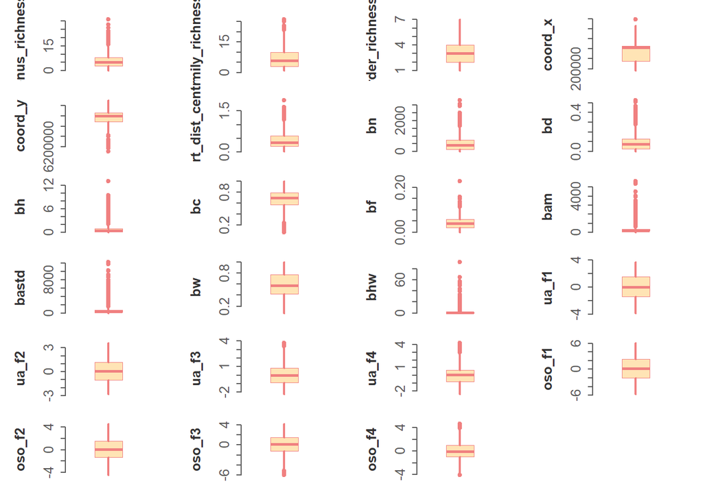

La même chose mais présenté autrement. Ce sont des *dotplots de Cleveland* qui présentent la distribution des données (abscisse) en fonction de leur rang (ordonnée).

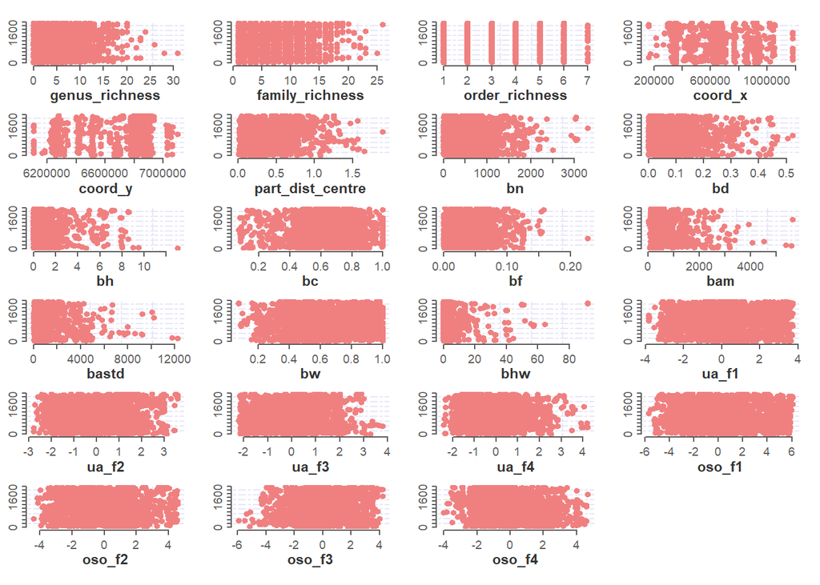

On voit qu’il y a quelques valeurs extrêmes pour certaines métriques. Ce sont des sites parisiens qui présentent des configurations assez atypiques, donc ce ne sont pas de vrais *outliers*.

## 1.3 Distribution et dissymétrie

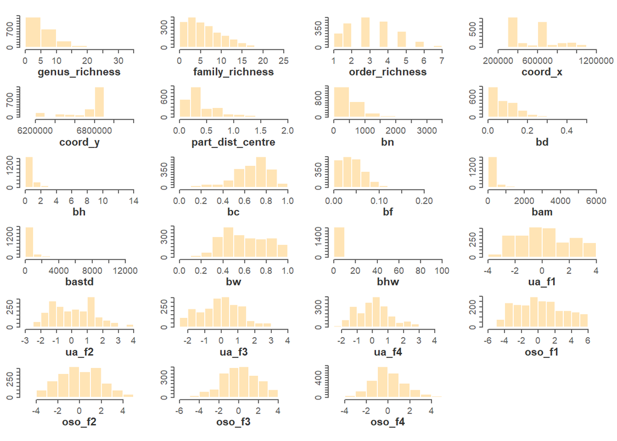

On a des variables très peu normales, avec des dissymétries prononcées pour BH, BAM, BASTD et surtout BHW. Mais ce sont surtout les valeurs de kurtosis qui crèvent le plafond. Il faudra peut-être transformer ces variables.

|  | Skewness | Excess kurtosis |
| --- | --- | --- |
| genus_richness | 1.086 | 1.527 |
| family_richness | 0.872 | 0.420 |
| order_richness | 0.283 | -0.495 |
| coord_x | 0.596 | -0.544 |
| coord_y | -1.312 | 0.465 |
| part_dist_centre | 1.251 | 1.307 |
| bn | 1.555 | 3.618 |
| bd | 1.687 | 3.881 |
| bh | 3.606 | 16.139 |
| bc | -0.926 | 1.006 |
| bf | 0.865 | 1.602 |
| bam | 4.142 | 23.655 |
| bastd | 3.832 | 20.004 |
| bw | 0.160 | -0.891 |
| bhw | 7.377 | 72.489 |
| ua_f1 | 0.151 | -0.970 |
| ua_f2 | 0.265 | -0.655 |
| ua_f3 | 0.187 | -0.393 |
| ua_f4 | 0.490 | 0.177 |
| oso_f1 | 0.172 | -0.938 |
| oso_f2 | 0.072 | -0.671 |
| oso_f3 | -0.114 | -0.331 |
| oso_f4 | 0.433 | 0.037 |

## 1.4 Relations bivariées

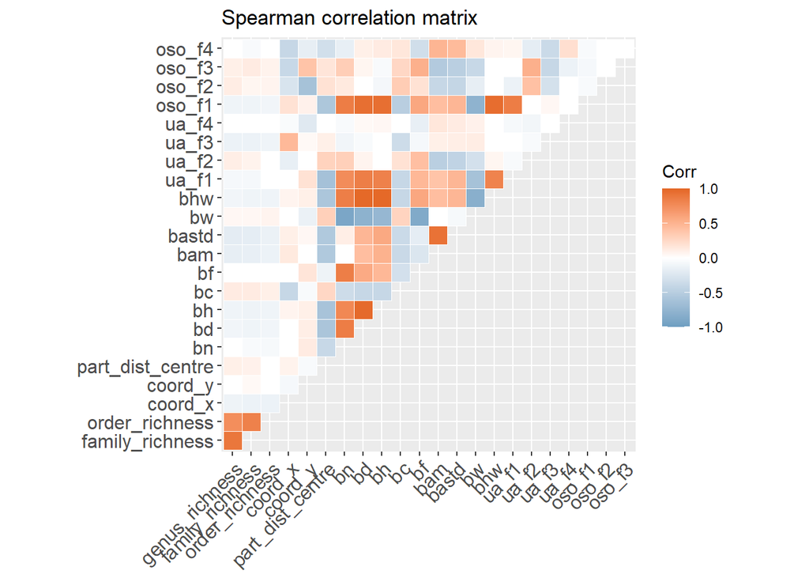

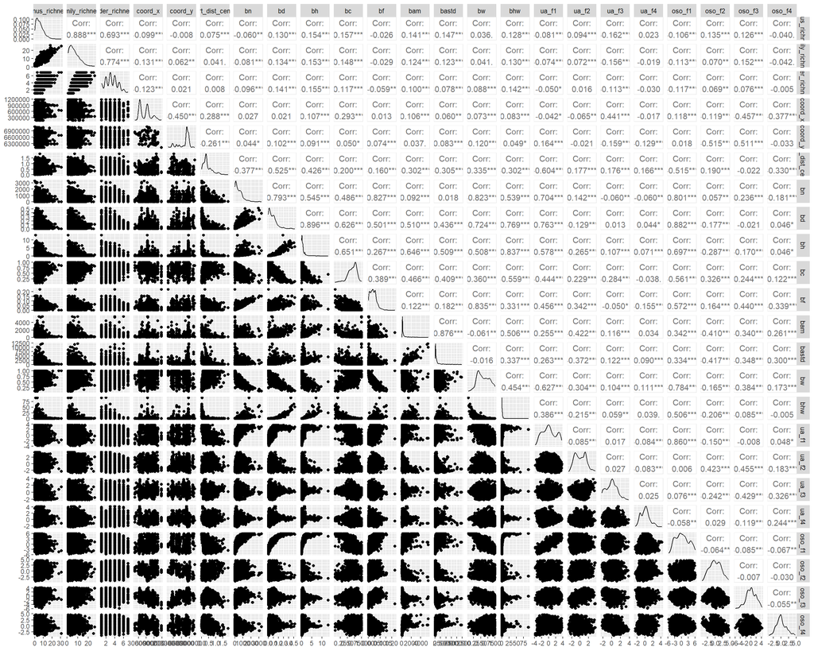

# 2 Analyses statistiques

## 2.1 Modélisation de la richesse en genres

Ci-dessous, les résultats des modèles pour expliquer la **richesse en genre** (i.e. le nombre de genres ou de sous-familles d’arthropodes observés sur les fleurs suivies).

A noter que les variables avec des ordres de grandeurs trop différents ont été standardisées, et celles qui avaient des distributions trop dissymétriques ont été transformées (log ou racine carré). Celles intervenant dans des interactions ont également été centrées pour éviter les problèmes de multicollinéarité.

Les données étant surdispersées, j’ai utilisé des GLMM avec une distribution **négative binomiale**. J’utilise les facteurs *ville* et *espèce de fleur* comme **effets aléatoires** dans les modèles (qui sont donc mixtes). J’ai fait différents essais de combinaisons de métriques pour obtenir des modèles fiable : peu de multicollinéarité, d’autocorrélation résiduelle, d’outliers, de divergences… Toutefois, faute de temps, je n’ai pas fait des diagnostiques aussi poussés que d’ordinaire. NOTE IMPORTANTE : les GLM négatifs binomiaux modélisent la réponse en échelle logarithmique. Il faut donc **exponentialiser** les coefficients (et l’intercept) pour reconvertir les valeurs dans l’échelle réelle de la réponse (i.e. des nombres de genres).

Voici le meilleur modèle additif (sans interaction) que j’ai trouvé :

```r
sppGNa_glmm2 <- glmmTMB::glmmTMB(genus_richness ~ dist_centre + log_bn + bc + log_bam + bw + ua_f2 + ua_f3 + longitude + latitude + (1|city) + (1|flower_sp), data = srich_arthro3, family = glmmTMB::nbinom2(link = "log"))
summary(sppGNa_glmm2) # AIC = 10887.1
```

```
##  Family: nbinom2  ( log )
## Formula:
## genus_richness ~ dist_centre + log_bn + bc + log_bam + bw + ua_f2 +
##     ua_f3 + longitude + latitude + (1 | city) + (1 | flower_sp)
## Data: srich_arthro3
##
##      AIC      BIC   logLik deviance df.resid
##  10887.1  10960.5  -5430.5  10861.1     2092
##
## Random effects:
##
## Conditional model:
##  Groups    Name        Variance Std.Dev.
##  city      (Intercept) 0.07443  0.2728
##  flower_sp (Intercept) 0.10066  0.3173
## Number of obs: 2105, groups:  city, 55; flower_sp, 13
##
## Dispersion parameter for nbinom2 family (): 5.97
##
## Conditional model:
##              Estimate Std. Error z value Pr(>|z|)
## (Intercept)  1.996603   0.355607   5.615 1.97e-08 ***
## dist_centre -0.086809   0.068244  -1.272  0.20336
## log_bn       0.082641   0.061610   1.341  0.17980
## bc           0.003038   0.120314   0.025  0.97986
## log_bam     -0.301262   0.062807  -4.797 1.61e-06 ***
## bw           0.467320   0.150018   3.115  0.00184 **
## ua_f2        0.017847   0.013456   1.326  0.18474
## ua_f3       -0.030196   0.014845  -2.034  0.04194 *
## longitude   -0.014140   0.042334  -0.334  0.73838
## latitude     0.001770   0.039610   0.045  0.96436
## ---
## Signif. codes:  0 '***' 0.001 '**' 0.01 '*' 0.05 '.' 0.1 ' ' 1
```

Il donne d’assez bons diagnostiques mais on retrouve cependant une **autocorrélation spatiale résiduelle** et des valeurs de VIF qui pourraient être plus basses (léger risque d’inflation de l’erreur de Type I) :

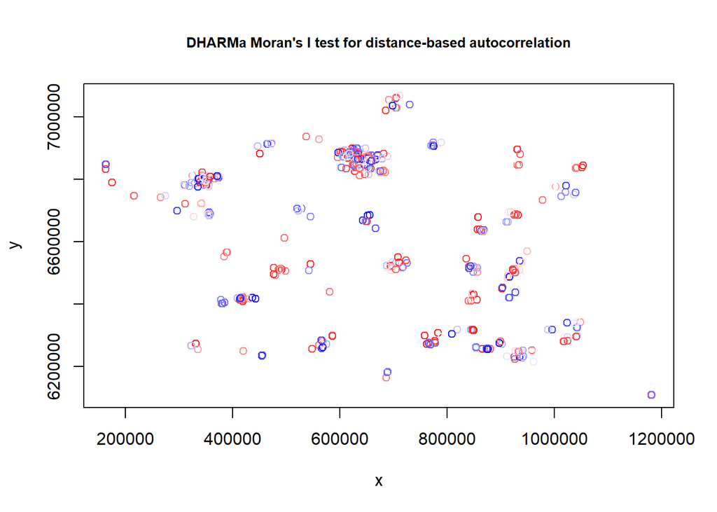

```
    DHARMa Moran's I test for distance-based autocorrelation

data:  simu.resid
observed = 0.13757016, expected = -0.00047529, sd = 0.00775649, p-value
< 2.2e-16
alternative hypothesis: Distance-based autocorrelation
```

[output not shown]

Les résultats montrent: * Un **effet négatif assez fort** de la *taille moyenne des îlots bâtis* (métrique *BAM*) sur la richesse en genres d’arthropodes. * Un **effet positif fort** de la *proportion de trouées* (métrique *BW*) en bordure d’îlot ! * Un faible effet d’*UA_F3*, mais qui disparait si l’on rajoute des interactions entre métriques. A noter que les **tailles d’effet** sont assez gros pour *BAM* et *BW* à en juger par le rapport entre les coefficients estimés pour ces prédicteurs et l’intercept.

Le modèle interactif est cependant légèrement meilleur :

```r
sppGNa_glmm3 <- glmmTMB::glmmTMB(genus_richness ~ dist_centre + c.log_bn * c.bc * c.log_bam + bw + ua_f2 + ua_f3 + longitude + latitude + (1|city) + (1|flower_sp), data = srich_arthro3, family = glmmTMB::nbinom2(link = "log"))
summary(sppGNa_glmm3) # AIC = 10886.1
```

```
##  Family: nbinom2  ( log )
## Formula:          genus_richness ~ dist_centre + c.log_bn * c.bc * c.log_bam +
##     bw + ua_f2 + ua_f3 + longitude + latitude + (1 | city) +
##     (1 | flower_sp)
## Data: srich_arthro3
##
##      AIC      BIC   logLik deviance df.resid
##  10886.1  10982.2  -5426.0  10852.1     2088
##
## Random effects:
##
## Conditional model:
##  Groups    Name        Variance Std.Dev.
##  city      (Intercept) 0.07067  0.2658
##  flower_sp (Intercept) 0.10044  0.3169
## Number of obs: 2105, groups:  city, 55; flower_sp, 13
##
## Dispersion parameter for nbinom2 family ():    6
##
## Conditional model:
##                          Estimate Std. Error z value Pr(>|z|)
## (Intercept)              1.533062   0.147120  10.420  < 2e-16 ***
## dist_centre             -0.107405   0.068520  -1.568   0.1170
## c.log_bn                 0.047751   0.063497   0.752   0.4520
## c.bc                     0.002802   0.137728   0.020   0.9838
## c.log_bam               -0.349701   0.084247  -4.151 3.31e-05 ***
## bw                       0.421484   0.156844   2.687   0.0072 **
## ua_f2                    0.006874   0.014489   0.474   0.6352
## ua_f3                   -0.024672   0.015246  -1.618   0.1056
## longitude               -0.015124   0.041651  -0.363   0.7165
## latitude                 0.009249   0.039211   0.236   0.8135
## c.log_bn:c.bc            0.384567   0.166821   2.305   0.0212 *
## c.log_bn:c.log_bam       0.015426   0.108302   0.142   0.8867
## c.bc:c.log_bam           0.156482   0.261085   0.599   0.5489
## c.log_bn:c.bc:c.log_bam -0.574243   0.268668  -2.137   0.0326 *
## ---
## Signif. codes:  0 '***' 0.001 '**' 0.01 '*' 0.05 '.' 0.1 ' ' 1
```

On observe que les effets de *BW* et de *BAM* sont consistants malgré les **effets d’interaction** significatifs.

Ci-dessous, le graphique des effets marginaux des variables qui interagissent (les valeurs utilisées pour illustrer ce graphique sont les **quartiles**) :

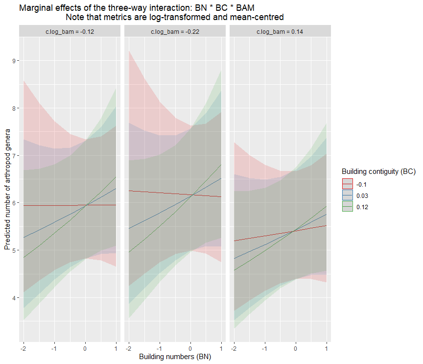

Et la même chose mais avec les valeurs MIN et MAX au lieu des quartiles :

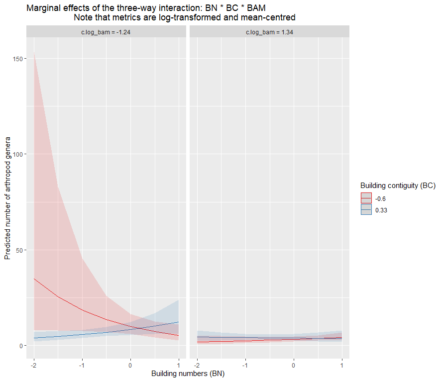

On observe donc : * Que les erreurs standards sont assez grandes mais les effets d’interactions sont clairs. * Un **effet positif** du *nombre de bâtiments* (*BN*) sur la richesse en genres d’arthropodes, qui est d’autant plus fort que la *contiguité du bâti* l’est aussi et ce, qu’elle que soit la *taille des îlots bâtis* (même si la richesse décline lorsque cette taille augmente trop).

## 2.2 Modélisation de la richesse en familles

Globalement, ça donne la même chose.

```r
sppFMa_glmm1 <- glmmTMB::glmmTMB(family_richness ~ dist_centre + c.log_bn * c.bc * c.log_bam + bw + ua_f2 + ua_f3 + longitude + latitude + (1|city) + (1|flower_sp), data = srich_arthro3, family = glmmTMB::nbinom2(link = "log"))
summary(sppFMa_glmm1) # AIC = 10962.7
```

```
##  Family: nbinom2  ( log )
## Formula:
## family_richness ~ dist_centre + c.log_bn * c.bc * c.log_bam +
##     bw + ua_f2 + ua_f3 + longitude + latitude + (1 | city) +
##     (1 | flower_sp)
## Data: srich_arthro3
##
##      AIC      BIC   logLik deviance df.resid
##  10962.7  11058.8  -5464.4  10928.7     2088
##
## Random effects:
##
## Conditional model:
##  Groups    Name        Variance Std.Dev.
##  city      (Intercept) 0.05889  0.2427
##  flower_sp (Intercept) 0.11660  0.3415
## Number of obs: 2105, groups:  city, 55; flower_sp, 13
##
## Dispersion parameter for nbinom2 family (): 9.03
##
## Conditional model:
##                          Estimate Std. Error z value Pr(>|z|)
## (Intercept)              1.676366   0.140387  11.941  < 2e-16 ***
## dist_centre             -0.054980   0.060201  -0.913 0.361094
## c.log_bn                 0.013975   0.055307   0.253 0.800515
## c.bc                    -0.044174   0.120390  -0.367 0.713678
## c.log_bam               -0.289828   0.074018  -3.916 9.02e-05 ***
## bw                       0.307455   0.136491   2.253 0.024287 *
## ua_f2                    0.002814   0.012774   0.220 0.825642
## ua_f3                   -0.016653   0.013317  -1.251 0.211098
## longitude               -0.025670   0.037395  -0.686 0.492429
## latitude                 0.029808   0.035428   0.841 0.400134
## c.log_bn:c.bc            0.490254   0.146308   3.351 0.000806 ***
## c.log_bn:c.log_bam       0.028289   0.093879   0.301 0.763156
## c.bc:c.log_bam           0.099068   0.225257   0.440 0.660081
## c.log_bn:c.bc:c.log_bam -0.542807   0.232985  -2.330 0.019817 *
## ---
## Signif. codes:  0 '***' 0.001 '**' 0.01 '*' 0.05 '.' 0.1 ' ' 1
```

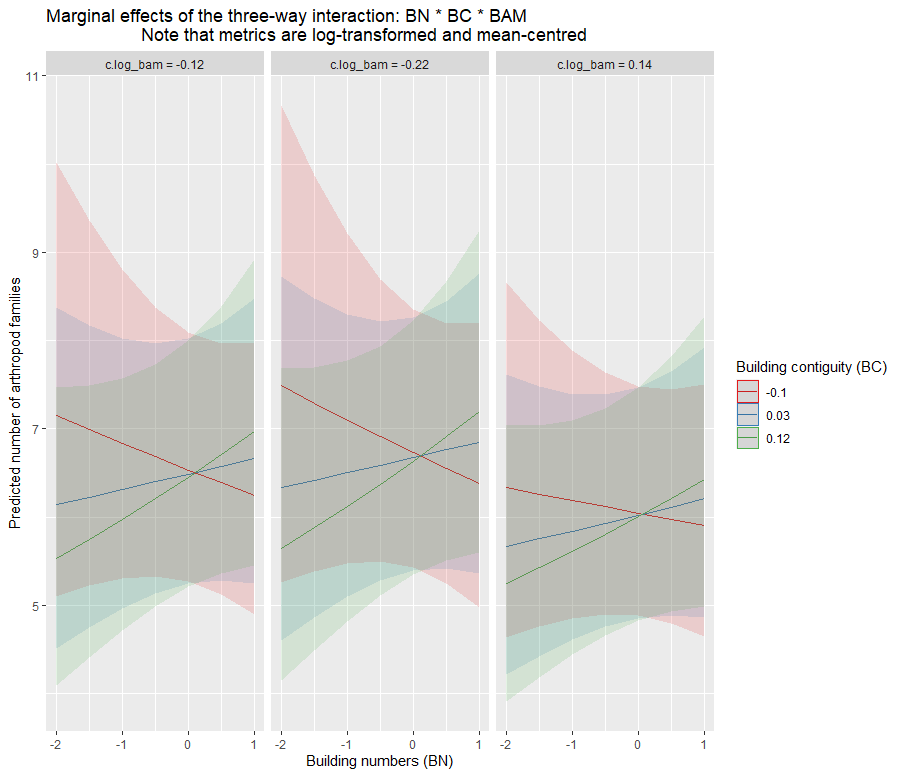

Ainsi, les grands îlots bâtis réduisent la richesse en genres ou en familles d’arthropodes alors que la présence de trouées le long des rues l’augmente. Par ailleurs, les tissus urbains composés de nombreux bâtiments plutôt contigus (unitaires ?) augmentent la richesse, à plus forte raison si leur taille est raisonnable.

Pour conclure, on peut aussi souligner le fait que c’est un **défi méthodologique** que de prendre en compte l’effet de nombreuses métriques qui sont aussi corrélées. Une solution pourrait être d’utiliser des méthodes qui sont plus robustes à la multicollinéarité comme des modèles de régression pénalisées (e.g. LASSO, Ridge) ou des approches de *machine learning* (arbres de régression, Random Forests…).